# Thera_Bank Project_Final

## Outlier Treatment

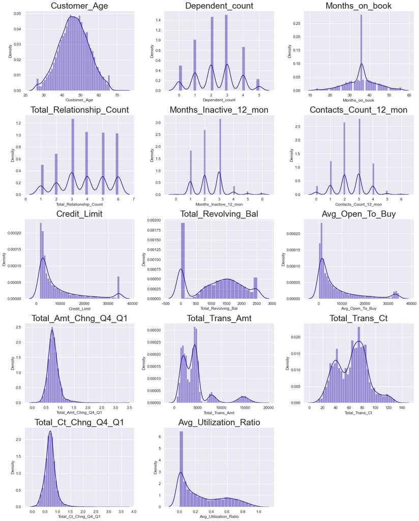

```python
#  first lets plot histogram of all plots
from scipy.stats import norm
all_col = df.select_dtypes(include=np.number).columns.tolist()
plt.figure(figsize=(17,75))

for i in range(len(all_col)):
    plt.subplot(18,3,i+1)
    sns.distplot(df[all_col[i]], kde=True)
    plt.tight_layout()
    plt.title(all_col[i],fontsize=25)


plt.show()
```

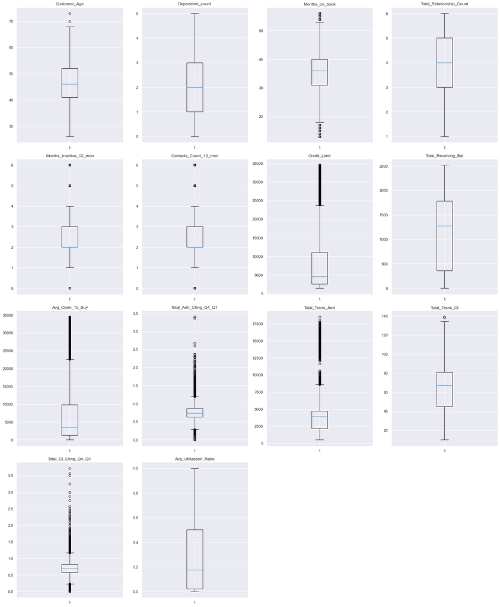

```python
# Highlighting the Numeric Colums
numeric_columns = df.select_dtypes(include=np.number).columns.tolist()

# lets plot the boxplots of all columns to view outliers
plt.figure(figsize=(20,30))

for i, variable in enumerate(numeric_columns):
                     plt.subplot(5,4,i+1)
                     plt.boxplot(df[variable],whis=1.5)
                     plt.tight_layout()
                     plt.title(variable)

plt.show()
```

- We can clearly see the variables vis-a-vis the ranges accounting for the presence of outliers

```python
# Lets treat outliers by flooring and capping
def treat_outliers(df,col):
    '''
    treats outliers in a varaible
    col: str, name of the numerical varaible
    df: data frame
    col: name of the column
    '''
    Q1=df[col].quantile(0.25) # 25th quantile
    Q3=df[col].quantile(0.75)  # 75th quantile
    IQR=Q3-Q1
    Lower_Whisker = Q1 - 1.5*IQR
    Upper_Whisker = Q3 + 1.5*IQR
    df[col] = np.clip(df[col], Lower_Whisker, Upper_Whisker) # all the values samller than Lower_Whisker will be assigned value of Lower_whisker
                                                            # and all the values above upper_whishker will be assigned value of upper_Whisker
    return df

def treat_outliers_all(df, col_list):
    '''
    treat outlier in all numerical varaibles
    col_list: list of numerical varaibles
    df: data frame
    '''
    for c in col_list:
        df = treat_outliers(df,c)

    return df
```

#### Treating the Outliers

```python
numerical_col = df.select_dtypes(include=np.number).columns.tolist()
df = treat_outliers_all(df,numerical_col)
```

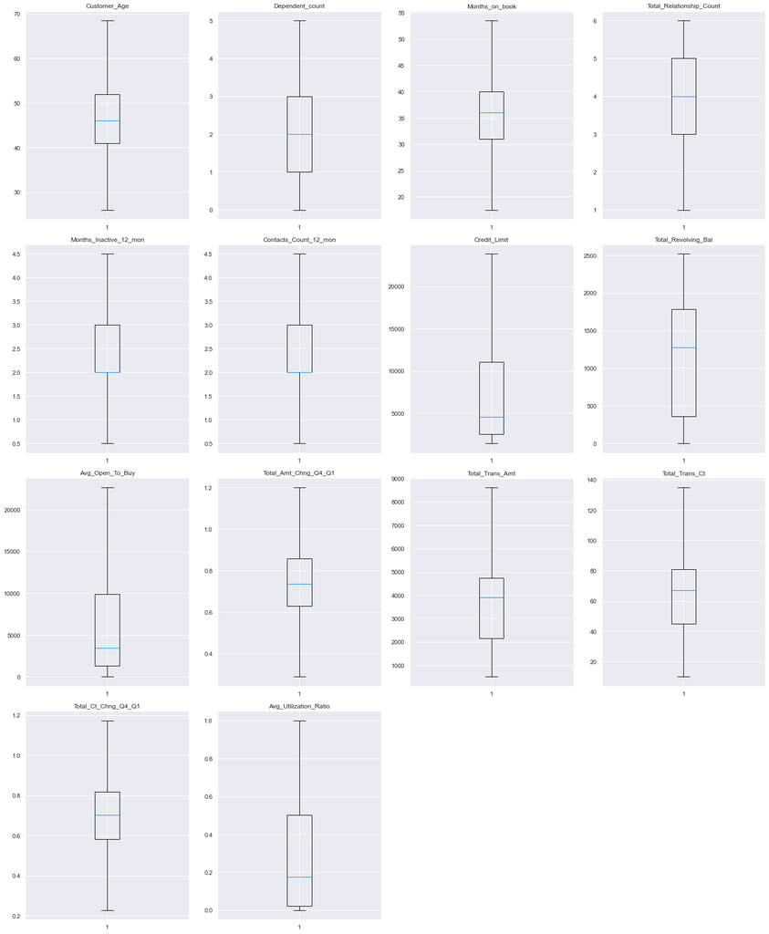

```python
# lets look at box plot to see if outliers has been treated or not
plt.figure(figsize=(20,30))

for i, variable in enumerate(numeric_columns):
                     plt.subplot(5,4,i+1)
                     plt.boxplot(df[variable],whis=1.5)
                     plt.tight_layout()
                     plt.title(variable)

plt.show()
```

## Model Building

### Approach

1. Feature Engineering
2. Partition the data into train and test set.
3. Build model on the train data.
4. Tune the model if required.
5. Test the data on test set.

### Feature Engineering

#### Let us treat the Unknown values in our dataset as Missing values

### Missing-Value Treatment

- We will use KNN imputer to impute missing values.
- `KNNImputer`: Each sample's missing values are imputed by looking at the n_neighbors nearest neighbors found in the training set. Default value for n_neighbors=5.
- KNN imputer replaces missing values using the average of k nearest non-missing feature values.
- Nearest points are found based on euclidean distance.

```python
imputer = KNNImputer(n_neighbors=5)
```

```python
df1 = df.copy()
```

```python
# Let us replace the unknown values with Nan values for modelling

df1['Marital_Status'] = df1['Marital_Status'].replace('Unknown',np.nan)
df1['Education_Level'] = df1['Education_Level'].replace('Unknown',np.nan)
df1['Income_Category'] = df1['Income_Category'].replace('Unknown',np.nan)
```

```python
cols = df1.select_dtypes(include=['object','category'])
for i in cols.columns:
    print(df1[i].value_counts())
    print('*'*30)
```

```
Existing Customer    8500
Attrited Customer    1627
Name: Attrition_Flag, dtype: int64
F    5358
M    4769
Name: Gender, dtype: int64
Graduate         3128
High School      2013
Uneducated       1487
College          1013
Post-Graduate     516
Doctorate         451
Name: Education_Level, dtype: int64
Married     4687
Single      3943
Divorced     748
Name: Marital_Status, dtype: int64
Less than $40K    3561
$40K - $60K       1790
$80K - $120K      1535
$60K - $80K       1402
$120K +            727
Name: Income_Category, dtype: int64
Blue        9436
Silver       555
Gold         116
Platinum      20
Name: Card_Category, dtype: int64
```

```python
# Let us pass class values for our target variable, Attrition_Flag prior to Modelling
df1['Attrition_Flag'] = df1['Attrition_Flag'].apply(lambda x : 1 if x== "Attrited Customer" else 0 )
```

```python
# we need to pass numerical values for each categorical column for KNN imputation so we will label encode them

gender = {'F':1, 'M':2}
df1['Gender']=df1['Gender'].map(gender)

marital_status = {'Married':1,'Single':2, 'Divorced':3}
df1['Marital_Status']=df1['Marital_Status'].map(marital_status)

education_level = {'Graduate':1, 'High School':2, 'Uneducated':3, 'College':4, 'Post-Graduate':5, 'Doctorate':6}
df1['Education_Level']=df1['Education_Level'].map(education_level)

income_category = {'Less than $40K':1, '$40K - $60K':2, '$80K - $120K':3, '$60K - $80K':4, '$120K +':5}
df1['Income_Category']=df1['Income_Category'].map(income_category)

card_category = {'Blue':1, 'Silver':2, 'Gold':3, 'Platinum':4}
df1['Card_Category']=df1['Card_Category'].map(card_category)
```

```python
df1.head(10)
```

|  | Attrition_Flag | Customer_Age | Gender | Dependent_count | Education_Level | Marital_Status | Income_Category | Card_Category | Months_on_book | Total_Relationship_Count | Months_Inactive_12_mon | Contacts_Count_12_mon | Credit_Limit | Total_Revolving_Bal | Avg_Open_To_Buy | Total_Amt_Chng_Q4_Q1 | Total_Trans_Amt | Total_Trans_Ct | Total_Ct_Chng_Q4_Q1 | Avg_Utilization_Ratio |
| --- | --- | --- | --- | --- | --- | --- | --- | --- | --- | --- | --- | --- | --- | --- | --- | --- | --- | --- | --- | --- |
| 0 | 0 | 45.0 | 2 | 3 | 2 | 1 | 4 | 1 | 39.0 | 5 | 1.0 | 3.0 | 12691.00 | 777 | 11914.00 | 1.201 | 1144.0 | 42 | 1.172 | 0.061 |
| 1 | 0 | 49.0 | 1 | 5 | 1 | 2 | 1 | 1 | 44.0 | 6 | 1.0 | 2.0 | 8256.00 | 864 | 7392.00 | 1.201 | 1291.0 | 33 | 1.172 | 0.105 |
| 2 | 0 | 51.0 | 2 | 3 | 1 | 1 | 3 | 1 | 36.0 | 4 | 1.0 | 0.5 | 3418.00 | 0 | 3418.00 | 1.201 | 1887.0 | 20 | 1.172 | 0.000 |
| 3 | 0 | 40.0 | 1 | 4 | 2 | NaN | 1 | 1 | 34.0 | 3 | 4.0 | 1.0 | 3313.00 | 2517 | 796.00 | 1.201 | 1171.0 | 20 | 1.172 | 0.760 |
| 4 | 0 | 40.0 | 2 | 3 | 3 | 1 | 4 | 1 | 21.0 | 5 | 1.0 | 0.5 | 4716.00 | 0 | 4716.00 | 1.201 | 816.0 | 28 | 1.172 | 0.000 |
| 5 | 0 | 44.0 | 2 | 2 | 1 | 1 | 2 | 1 | 36.0 | 3 | 1.0 | 2.0 | 4010.00 | 1247 | 2763.00 | 1.201 | 1088.0 | 24 | 0.846 | 0.311 |
| 6 | 0 | 51.0 | 2 | 4 | NaN | 1 | 5 | 3 | 46.0 | 6 | 1.0 | 3.0 | 23836.25 | 2264 | 22660.75 | 1.201 | 1330.0 | 31 | 0.722 | 0.066 |
| 7 | 0 | 32.0 | 2 | 0 | 2 | NaN | 4 | 2 | 27.0 | 2 | 2.0 | 2.0 | 23836.25 | 1396 | 22660.75 | 1.201 | 1538.0 | 36 | 0.714 | 0.048 |
| 8 | 0 | 37.0 | 2 | 3 | 3 | 2 | 4 | 1 | 36.0 | 5 | 2.0 | 0.5 | 22352.00 | 2517 | 19835.00 | 1.201 | 1350.0 | 24 | 1.172 | 0.113 |
| 9 | 0 | 48.0 | 2 | 2 | 1 | 2 | 3 | 1 | 36.0 | 6 | 3.0 | 3.0 | 11656.00 | 1677 | 9979.00 | 1.201 | 1441.0 | 32 | 0.882 | 0.144 |

```python
# We are dropping Avg_Open_To_Buy because of its perfect correlation with Credt_Limit.
#This is an attempt at eliminating Multi-Collinearity
df1.drop(['Avg_Open_To_Buy'],axis=1,inplace=True)
```

```python
df1.head(10)
```

|  | Attrition_Flag | Customer_Age | Gender | Dependent_count | Education_Level | Marital_Status | Income_Category | Card_Category | Months_on_book | Total_Relationship_Count | Months_Inactive_12_mon | Contacts_Count_12_mon | Credit_Limit | Total_Revolving_Bal | Total_Amt_Chng_Q4_Q1 | Total_Trans_Amt | Total_Trans_Ct | Total_Ct_Chng_Q4_Q1 | Avg_Utilization_Ratio |
| --- | --- | --- | --- | --- | --- | --- | --- | --- | --- | --- | --- | --- | --- | --- | --- | --- | --- | --- | --- |
| 0 | 0 | 45.0 | 2 | 3 | 2 | 1 | 4 | 1 | 39.0 | 5 | 1.0 | 3.0 | 12691.00 | 777 | 1.201 | 1144.0 | 42 | 1.172 | 0.061 |
| 1 | 0 | 49.0 | 1 | 5 | 1 | 2 | 1 | 1 | 44.0 | 6 | 1.0 | 2.0 | 8256.00 | 864 | 1.201 | 1291.0 | 33 | 1.172 | 0.105 |
| 2 | 0 | 51.0 | 2 | 3 | 1 | 1 | 3 | 1 | 36.0 | 4 | 1.0 | 0.5 | 3418.00 | 0 | 1.201 | 1887.0 | 20 | 1.172 | 0.000 |
| 3 | 0 | 40.0 | 1 | 4 | 2 | NaN | 1 | 1 | 34.0 | 3 | 4.0 | 1.0 | 3313.00 | 2517 | 1.201 | 1171.0 | 20 | 1.172 | 0.760 |
| 4 | 0 | 40.0 | 2 | 3 | 3 | 1 | 4 | 1 | 21.0 | 5 | 1.0 | 0.5 | 4716.00 | 0 | 1.201 | 816.0 | 28 | 1.172 | 0.000 |
| 5 | 0 | 44.0 | 2 | 2 | 1 | 1 | 2 | 1 | 36.0 | 3 | 1.0 | 2.0 | 4010.00 | 1247 | 1.201 | 1088.0 | 24 | 0.846 | 0.311 |
| 6 | 0 | 51.0 | 2 | 4 | NaN | 1 | 5 | 3 | 46.0 | 6 | 1.0 | 3.0 | 23836.25 | 2264 | 1.201 | 1330.0 | 31 | 0.722 | 0.066 |
| 7 | 0 | 32.0 | 2 | 0 | 2 | NaN | 4 | 2 | 27.0 | 2 | 2.0 | 2.0 | 23836.25 | 1396 | 1.201 | 1538.0 | 36 | 0.714 | 0.048 |
| 8 | 0 | 37.0 | 2 | 3 | 3 | 2 | 4 | 1 | 36.0 | 5 | 2.0 | 0.5 | 22352.00 | 2517 | 1.201 | 1350.0 | 24 | 1.172 | 0.113 |
| 9 | 0 | 48.0 | 2 | 2 | 1 | 2 | 3 | 1 | 36.0 | 6 | 3.0 | 3.0 | 11656.00 | 1677 | 1.201 | 1441.0 | 32 | 0.882 | 0.144 |

## Split Data

- When classification problems exhibit a significant imbalance in the distribution of the target classes, it is good to use stratified sampling to ensure that relative class frequencies are approximately preserved in train and test sets.
- This is done using the `stratify` parameter in the train_test_split function.

```python
# We are dropping Avg_Open_To_Buy because of its perfect correlation with Credt_Limit. This is an attempt at eliminating Multi-Collinearity
X = df1.drop(columns='Attrition_Flag')
y = df1['Attrition_Flag']
```

```python
df1.Attrition_Flag.value_counts()
```

```
0    8500
1    1627
Name: Attrition_Flag, dtype: int64
```

```python
X.head()
```

|  | Customer_Age | Gender | Dependent_count | Education_Level | Marital_Status | Income_Category | Card_Category | Months_on_book | Total_Relationship_Count | Months_Inactive_12_mon | Contacts_Count_12_mon | Credit_Limit | Total_Revolving_Bal | Total_Amt_Chng_Q4_Q1 | Total_Trans_Amt | Total_Trans_Ct | Total_Ct_Chng_Q4_Q1 | Avg_Utilization_Ratio |
| --- | --- | --- | --- | --- | --- | --- | --- | --- | --- | --- | --- | --- | --- | --- | --- | --- | --- | --- |
| 0 | 45.0 | 2 | 3 | 2 | 1 | 4 | 1 | 39.0 | 5 | 1.0 | 3.0 | 12691.0 | 777 | 1.201 | 1144.0 | 42 | 1.172 | 0.061 |
| 1 | 49.0 | 1 | 5 | 1 | 2 | 1 | 1 | 44.0 | 6 | 1.0 | 2.0 | 8256.0 | 864 | 1.201 | 1291.0 | 33 | 1.172 | 0.105 |
| 2 | 51.0 | 2 | 3 | 1 | 1 | 3 | 1 | 36.0 | 4 | 1.0 | 0.5 | 3418.0 | 0 | 1.201 | 1887.0 | 20 | 1.172 | 0.000 |
| 3 | 40.0 | 1 | 4 | 2 | NaN | 1 | 1 | 34.0 | 3 | 4.0 | 1.0 | 3313.0 | 2517 | 1.201 | 1171.0 | 20 | 1.172 | 0.760 |
| 4 | 40.0 | 2 | 3 | 3 | 1 | 4 | 1 | 21.0 | 5 | 1.0 | 0.5 | 4716.0 | 0 | 1.201 | 816.0 | 28 | 1.172 | 0.000 |

```python
y.head()
```

```
0    0
1    0
2    0
3    0
4    0
Name: Attrition_Flag, dtype: category
Categories (2, int64): [1, 0]
```

```python
X.shape
```

```
(10127, 18)
```

```python
# Splitting data into training and test set:
X_train, X_test, y_train, y_test = train_test_split(X, y, test_size=0.3, random_state=1,stratify=y)
print(X_train.shape, X_test.shape)
```

```
(7088, 18) (3039, 18)
```

```python
y.value_counts(1)
#y.value_counts(normalize=True) #If True then the object returned will contain the relative frequencies of the unique values.
```

```
0    0.83934
1    0.16066
Name: Attrition_Flag, dtype: float64
```

```python
y_test.value_counts(1)
```

```
0    0.839421
1    0.160579
Name: Attrition_Flag, dtype: float64
```

```python
X_train.shape
```

```
(7088, 18)
```

#### Resolving 'Unknown' values

```python
imputer = KNNImputer(n_neighbors=5)
```

```python
#Fit and transform the train data
X_train=pd.DataFrame(imputer.fit_transform(X_train),columns=X_train.columns)

#Transform the test data
X_test=pd.DataFrame(imputer.transform(X_test),columns=X_test.columns)
```

```python
#Checking that no column has missing values in train or test sets
print(X_train.isna().sum())
print('-'*30)
print(X_test.isna().sum())
```

```
Customer_Age                0
Gender                      0
Dependent_count             0
Education_Level             0
Marital_Status              0
Income_Category             0
Card_Category               0
Months_on_book              0
Total_Relationship_Count    0
Months_Inactive_12_mon      0
Contacts_Count_12_mon       0
Credit_Limit                0
Total_Revolving_Bal         0
Total_Amt_Chng_Q4_Q1        0
Total_Trans_Amt             0
Total_Trans_Ct              0
Total_Ct_Chng_Q4_Q1         0
Avg_Utilization_Ratio       0
dtype: int64
------------------------------
Customer_Age                0
Gender                      0
Dependent_count             0
Education_Level             0
Marital_Status              0
Income_Category             0
Card_Category               0
Months_on_book              0
Total_Relationship_Count    0
Months_Inactive_12_mon      0
Contacts_Count_12_mon       0
Credit_Limit                0
Total_Revolving_Bal         0
Total_Amt_Chng_Q4_Q1        0
Total_Trans_Amt             0
Total_Trans_Ct              0
Total_Ct_Chng_Q4_Q1         0
Avg_Utilization_Ratio       0
dtype: int64
```

```python
## Function to inverse the encoding
def inverse_mapping(x,y):
    inv_dict = {v: k for k, v in x.items()}
    X_train[y] = np.round(X_train[y]).map(inv_dict).astype('category')
    X_test[y] = np.round(X_test[y]).map(inv_dict).astype('category')
```

```python
inverse_mapping(gender,'Gender')
inverse_mapping(marital_status,'Marital_Status')
inverse_mapping(income_category,'Income_Category')
inverse_mapping(education_level,'Education_Level')
inverse_mapping(card_category,'Card_Category')
```

```python
### Checking inverse mapped categroical variables
cols = X_train.select_dtypes(include=['object','category'])
for i in cols.columns:
    print(X_train[i].value_counts())
    print('*'*30)
```

```
F    3770
M    3318
Name: Gender, dtype: int64
Graduate         2257
High School      1939
Uneducated       1441
College           770
Post-Graduate     369
Doctorate         312
Name: Education_Level, dtype: int64
Married     3505
Single      3081
Divorced     502
Name: Marital_Status, dtype: int64
Less than $40K    2616
$40K - $60K       1508
$80K - $120K      1366
$60K - $80K       1085
$120K +            513
Name: Income_Category, dtype: int64
Blue        6621
Silver       375
Gold          78
Platinum      14
Name: Card_Category, dtype: int64
```

### Encoding Categorical Variables

```python
oneHotCols=["Gender","Card_Category","Income_Category","Education_Level","Marital_Status"]
X_train=pd.get_dummies(X_train,columns=oneHotCols,drop_first=True)
X_test=pd.get_dummies(X_test,columns=oneHotCols,drop_first=True)
print(X_train.shape, X_test.shape)
```

```
(7088, 28) (3039, 28)
```

## Model evaluation criterion

### Model can make wrong predictions as:

1. Predicting a customer will attrite and the customer doesn't
2. Predicting a customer will not attrite and the customer actually does

### Which case is more important?

- Predicting that a customer will not attrite but actually does i.e. losing on a valuable customer that would have added value to Thera Bank

### How to reduce this loss i.e need to reduce False Negatives?

- Thera Bank wants Recall to be maximized, the greater the Recall the higher the chances of minimizing false negatives. Hence, the focus should be on increasing Recall or minimizing the false negatives or in other words identifying the true positives(i.e. Class 1) so that the bank can provide value oriented solutions, perks and incentives to retain customers thereby optimizing the overall initiative to increase credit card applications and ultimately income vis-a-vis turnover in transaction volumes.

**Let's define function to provide metric scores(accuracy,recall and precision) on train and test set and a function to show confusion matrix so that we do not have use the same code repetitively while evaluating models.**

```python
models = []  # Empty list to store all the models

# Appending pipelines for each model into the list
models.append(
    (
        "LR",
        Pipeline(
            steps=[
                ("scaler", StandardScaler()),
                ("log_reg", LogisticRegression(random_state=1)),
            ]
        ),
    )
)
models.append(
    (
        "BG",
        Pipeline(
            steps=[
                ("scaler", StandardScaler()),
                ("bagging", BaggingClassifier(random_state=1)),
            ]
        ),
    )
)
models.append(
    (
        "RF",
        Pipeline(
            steps=[
                ("scaler", StandardScaler()),
                ("random_forest", RandomForestClassifier(random_state=1)),
            ]
        ),
    )
)
models.append(
    (
        "GBC",
        Pipeline(
            steps=[
                ("scaler", StandardScaler()),
                ("gradient_boosting", GradientBoostingClassifier(random_state=1)),
            ]
        ),
    )
)
models.append(
    (
        "ADB",
        Pipeline(
            steps=[
                ("scaler", StandardScaler()),
                ("adaboost", AdaBoostClassifier(random_state=1)),
            ]
        ),
    )
)
models.append(
    (
        "XGB",
        Pipeline(
            steps=[
                ("scaler", StandardScaler()),
                ("xgboost", XGBClassifier(random_state=1,eval_metric='logloss')),
            ]
        ),
    )
)
models.append(
    (
        "DTREE",
        Pipeline(
            steps=[
                ("scaler", StandardScaler()),
                ("decision_tree", DecisionTreeClassifier(random_state=1)),
            ]
        ),
    )
)

results = []  # Empty list to store all model's CV scores
names = []  # Empty list to store name of the models

# loop through all models to get the mean cross validated score
for name, model in models:
    scoring = "recall"
    kfold = StratifiedKFold(
        n_splits=5, shuffle=True, random_state=1
    )  # Setting number of splits equal to 5
    cv_result = cross_val_score(
        estimator=model, X=X_train, y=y_train, scoring=scoring, cv=kfold
    )
    results.append(cv_result)
    names.append(name)
    print("{}: {}".format(name, cv_result.mean() * 100))
```

```
LR: 61.54726022103717
BG: 81.29608161372595
RF: 77.52453821779118
GBC: 83.84457840636834
ADB: 82.7923332560476
XGB: 87.44261534894505
DTREE: 79.27776489682354
```

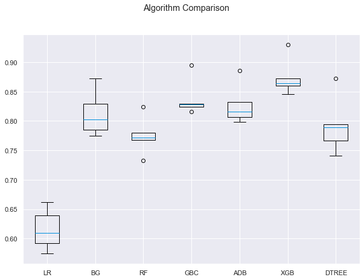

```python
# Plotting boxplots for CV scores of all models defined above
fig = plt.figure(figsize=(10, 7))

fig.suptitle("Algorithm Comparison")
ax = fig.add_subplot(111)

plt.boxplot(results)
ax.set_xticklabels(names)

plt.show()
```

- Though GBClassifier,XGBClassifier and AdaBoost Classifiers are the best models, for computationally expensive reason,we shall tune Bagging, AdaBoost and GBClassifier

```python
##  Function to calculate different metric scores of the model - Accuracy, Recall and Precision
def get_metrics_score(model,train,test,train_y,test_y,flag=True):
    '''
    model : classifier to predict values of X

    '''
    # defining an empty list to store train and test results
    score_list=[]

    pred_train = model.predict(train)
    pred_test = model.predict(test)

    train_acc = model.score(train,train_y)
    test_acc = model.score(test,test_y)

    train_recall = metrics.recall_score(train_y,pred_train)
    test_recall = metrics.recall_score(test_y,pred_test)

    train_precision = metrics.precision_score(train_y,pred_train)
    test_precision = metrics.precision_score(test_y,pred_test)

    score_list.extend((train_acc,test_acc,train_recall,test_recall,train_precision,test_precision))

    # If the flag is set to True then only the following print statements will be displayed. The default value is set to True.
    if flag == True:
        print("Accuracy on training set : ",model.score(train,train_y))
        print("Accuracy on test set : ",model.score(test,test_y))
        print("Recall on training set : ",metrics.recall_score(train_y,pred_train))
        print("Recall on test set : ",metrics.recall_score(test_y,pred_test))
        print("Precision on training set : ",metrics.precision_score(train_y,pred_train))
        print("Precision on test set : ",metrics.precision_score(test_y,pred_test))

    return score_list # returning the list with train and test scores
```

```python
def make_confusion_matrix(model,y_actual,labels=[1, 0]):
    '''
    model : classifier to predict values of X
    y_actual : ground truth

    '''
    y_predict = model.predict(X_test)
    cm=metrics.confusion_matrix( y_actual, y_predict, labels=[0, 1])
    df_cm = pd.DataFrame(cm, index = [i for i in ["Actual - No","Actual - Yes"]],
                  columns = [i for i in ['Predicted - No','Predicted - Yes']])
    group_counts = ["{0:0.0f}".format(value) for value in
                cm.flatten()]
    group_percentages = ["{0:.2%}".format(value) for value in
                         cm.flatten()/np.sum(cm)]
    labels = [f"{v1}\n{v2}" for v1, v2 in
              zip(group_counts,group_percentages)]
    labels = np.asarray(labels).reshape(2,2)
    plt.figure(figsize = (10,7))
    sns.heatmap(df_cm, annot=labels,fmt='')
    plt.ylabel('True label')
    plt.xlabel('Predicted label')
```